# Coursera WashU Dtasci Capstone Project: BLIGHT

Loading libraries

Setting data location, make sure the files below are available so the rest runs

```r
datadir <- "../data"
list.files(datadir)
```

```
[1] "detroit-311.csv"                "detroit-blight-violations.csv"
[3] "detroit-crime.csv"              "detroit-demolition-permits.tsv"
[5] "detroit-PARCELS.csv"
```

Loading data permits – mainly blight incidents

```r
data_permits <- read_tsv(paste(datadir, "detroit-demolition-permits.tsv", sep="/"))
head(data_permits)
```

| PERMIT_NO | PERMIT_APPLIED | PERMIT_ISSUED | PERMIT_EXPIRES | SITE_ADDRESS | BETWEEN1 | PARCEL_NO | LOT_NUMBER | SUBDIVISION | CASE_TYPE | CASE_DESCRIPTION | LEGAL_USE | ESTIMATED_COST | PARCEL_SIZE | PARCEL_CLUSTER_SECTOR | STORIES | PARCEL_FLOOR_AREA | PARCEL_GROUND_AREA | PRC_AKA_ADDRESS | BLD_PERMIT_TYPE | PERMIT_DESCRIPTION | BLD_PERMIT_DESC | BLD_TYPE_USE | RESIDENTIAL | DESCRIPTION | BLD_TYPE_CONST_COD | BLD_ZONING_DIST | BLD_USE_GROUP | BLD_BASEMENT | FEE_TYPE | … |
| --- | --- | --- | --- | --- | --- | --- | --- | --- | --- | --- | --- | --- | --- | --- | --- | --- | --- | --- | --- | --- | --- | --- | --- | --- | --- | --- | --- | --- | --- | --- |
| BLD2015-03955 | 8/28/15 | 8/28/15 | NA | 4331 BARHAM | BETWEEN VOIGHT AND WAVENEY | 21 65525-6 | S15 | NA | BLD | Building Permit | I - FAM DWLG | NA | 5184 | 3 | NA | 0 | 829 | NA | Dismantle | NA | NA | One Family Dwelling | RESIDENTIAL | NA | 5B | R2 | R3 | Y | WPMT | … |
| BLD2015-04083 | 8/28/15 | 8/28/15 | NA | 9707 BESSEMORE | BETWEEN VINTON AND GRATIOT | 19 2312. | 40 | NA | BLD | Building Permit | SINGLE FAMILY DWELLING | NA | 3006 | 1 | 1 | 0 | 799 | NA | Dismantle | NA | NA | One Family Dwelling | RESIDENTIAL | NA | 5B | R1 | R3 | NA | WPMT | … |
| BLD2015-03976 | 8/28/15 | 8/28/15 | NA | 5315 BERKSHIRE | BETWEEN SOUTHAMPTON AND FRANKFORT | 21 69321. | 445 | NA | BLD | Building Permit | I - FAM DWLG | NA | 4487 | 3 | NA | 0 | 675 | NA | Dismantle | NA | NA | One Family Dwelling | RESIDENTIAL | NA | 5B | R2 | R3 | Y | WPMT | … |
| BLD2015-03781 | 8/28/15 | 8/28/15 | NA | 16670 BRINGARD DR | BETWEEN CUSHING AND SHAKESPEARE | 21 25930. | 97 | NA | BLD | Building Permit | I - FAM DWLG | NA | 5532 | 2 | NA | 0 | 0 | NA | Dismantle | NA | NA | One Family Dwelling | RESIDENTIAL | NA | 5B | R2 | R3 | Y | WPMT | … |
| BLD2015-03677 | 8/28/15 | 8/28/15 | NA | 1454 BEATRICE | BETWEEN TORONTO AND GILROY | 20 12871.012 | 21 | NA | BLD | Building Permit | 1 - FAM DWLG | NA | 5184 | 5 | NA | 0 | 725 | NA | Dismantle | NA | NA | One Family Dwelling | RESIDENTIAL | NA | 5B | R2 | R3 | Y | WPMT | … |
| BLD2015-03914 | 8/28/15 | 8/28/15 | NA | 5035 BALFOUR | BETWEEN FRANKFORT AND WARREN | 21 68774. | 163 | NA | BLD | Building Permit | I - FAM DWLG | NA | 5706 | 3 | NA | 0 | 863 | NA | Dismantle | NA | NA | One Family Dwelling | RESIDENTIAL | NA | 5B | R2 | R3 | Y | WPMT | … |

Data permits exploration

```r
#converting to factors
cols <- c("CASE_TYPE", "CASE_DESCRIPTION", "LEGAL_USE", "BLD_PERMIT_TYPE",
          "PERMIT_DESCRIPTION", "BLD_PERMIT_DESC", "BLD_TYPE_USE", "RESIDENTIAL",
          "DESCRIPTION", "BLD_TYPE_CONST_COD", "BLD_ZONING_DIST", "BLD_USE_GROUP",
          "BLD_BASEMENT", "FEE_TYPE", "CSF_CREATED_BY","CONDITION_FOR_APPROVAL")
data_permits %<>% mutate_each_(funs(factor(.)),cols)
#converting $$ to numeric
cols <- c("PCF_AMT_PD", "PCF_AMT_DUE", "PCF_UPDATED","ESTIMATED_COST")
data_permits %<>% mutate_each_(funs(from_currency(.)),cols)
#converting to dates
cols <-c("PERMIT_APPLIED","PERMIT_ISSUED","PERMIT_EXPIRES")
# to use lubridate, need to figure it out --
data_permits %<>% mutate_each_(funs(parse_date_time(.,orders="mdy",tz="America/Detroit")),cols)
```

```
 3 failed to parse. 3 failed to parse. 3 failed to parse.
```

```r
summary(data_permits)
```

```
  PERMIT_NO         PERMIT_APPLIED                PERMIT_ISSUED
 Length:7133        Min.   :2010-05-20 00:00:00   Min.   :2010-05-20 00:00:00
 Class :character   1st Qu.:2012-08-15 00:00:00   1st Qu.:2012-08-15 00:00:00
 Mode  :character   Median :2013-03-12 00:00:00   Median :2013-03-12 00:00:00
                    Mean   :2013-07-07 20:39:12   Mean   :2013-07-07 22:37:45
                    3rd Qu.:2014-10-15 00:00:00   3rd Qu.:2014-10-17 00:00:00
                    Max.   :2015-08-28 00:00:00   Max.   :2015-08-28 00:00:00
                    NA's   :3                     NA's   :3
 PERMIT_EXPIRES                SITE_ADDRESS         BETWEEN1          PARCEL_NO
 Min.   :2010-11-20 00:00:00   Length:7133        Length:7133        Length:7133
 1st Qu.:2013-02-23 00:00:00   Class :character   Class :character   Class :character
 Median :2013-09-08 00:00:00   Mode  :character   Mode  :character   Mode  :character
 Mean   :2013-12-03 12:13:46
 3rd Qu.:2015-02-28 00:00:00
 Max.   :2016-12-05 00:00:00
 NA's   :183
  LOT_NUMBER        SUBDIVISION        CASE_TYPE         CASE_DESCRIPTION
 Length:7133        Length:7133        BLD:7133   Building Permit:7133
 Class :character   Class :character
 Mode  :character   Mode  :character




                  LEGAL_USE    ESTIMATED_COST    PARCEL_SIZE      PARCEL_CLUSTER_SECTOR
 ONE FAMILY DWELLING   :2709   Min.   :     0   Min.   :      0   Min.   : 1.000
 RES                   : 920   1st Qu.:  4525   1st Qu.:   3354   1st Qu.: 2.000
 ONE FAMILY            : 798   Median : 13470   Median :   4095   Median : 5.000
 TWO FAMILY DWELLING   : 479   Mean   : 18955   Mean   :  13540   Mean   : 4.656
 SINGLE FAMILY DWELLING: 358   3rd Qu.: 18750   3rd Qu.:   4932   3rd Qu.: 7.000
 (Other)               :1425   Max.   :448200   Max.   :2554576   Max.   :10.000
 NA's                  : 444   NA's   :6791     NA's   :45        NA's   :11
    STORIES       PARCEL_FLOOR_AREA PARCEL_GROUND_AREA PRC_AKA_ADDRESS     BLD_PERMIT_TYPE
 Min.   : 1.000   Min.   :      0   Min.   :    0.0    Length:7133        DISM     :5859
 1st Qu.: 1.000   1st Qu.:      0   1st Qu.:  630.0    Class :character   Dismantle:1274
 Median : 1.500   Median :      0   Median :  768.0    Mode  :character
 Mean   : 2.126   Mean   :   6830   Mean   :  742.3
 3rd Qu.: 2.000   3rd Qu.:      0   3rd Qu.:  912.0
 Max.   :26.000   Max.   :5102782   Max.   :27316.0
 NA's   :1426     NA's   :45        NA's   :45
```

[output cut: 61 more lines]

```
 3rd Qu.:48227
 Max.   :92606
 NA's   :179
                                                                                                                                                                                                                                                                           CONDITION_FOR_APPROVAL
 Call for inspection upon compliance.Ord. 290-H, 12-11-14.3, ET SEQ.CC: OWNER: Borman LLC.                     30600 Telegraph Rd.                     Bingham Farms, MI 48025CC: TENANT: LD Acquistion Co.                     P.O. Box 3429                     El Segunda, CA 90245:   1
 Remove all foundations from site and backfill.Ord. 290-H, 12-11-19.9, ET SEQ.                                                                                                                                                                                                        :   1
 NA's                                                                                                                                                                                                                                                                                 :7131




 site_location      owner_location     contractor_location     geom
 Length:7133        Length:7133        Length:7133         Length:7133
 Class :character   Class :character   Class :character    Class :character
 Mode  :character   Mode  :character   Mode  :character    Mode  :character
```

Extracting building lat longs

```r
data_permits %<>%
  #filter out permits that have no lat/long
  filter(grepl("\\([0-9\\.\\-]+, *[0-9\\.\\-]+\\)",site_location)) %>%
  #extracting lat longs
  mutate(lat = as.double(sub(".*\\(([0-9\\.\\-]+),.*","\\1", site_location))) %>%
  mutate(long = as.double(sub(".*, *([0-9\\.\\-]+).*","\\1", site_location))) %>%
  mutate(address_only = sub("([^\\(]+)\\([0-9\\.\\-]+,.*","\\1", site_location))
```

Create a list of buildings doing some magic to remove those entries whose lat/long stdev is larger than 10e-4 (~11m). Not much gets removed actually, but it’s consistent with steps below. Removed those records whose address was a lat/long (only ~40).

```r
bld_list_permit <- data_permits %>%
  mutate(r = sqrt(PARCEL_SIZE/pi) ) %>%
  select(address=address_only, PARCEL_NO, LOT_NUMBER, PERMIT_ISSUED, PARCEL_SIZE, lat, long, r) %>%
  filter(! grepl("\\([0-9\\.\\-]+, *[0-9\\.\\-]+\\)",address)) %>%
  arrange(address, desc(PERMIT_ISSUED)) %>%
  group_by(address) %>%
  mutate(sdlat=sd(lat), sdlong=sd(long)) %>%
  filter((sdlat<10e-4 && sdlong<10e-4) || (is.na(sdlat) && is.na(sdlong))) %>%
  filter(long > -83.3 && long < -82.8) %>%
  filter(lat > 42.2 && lat < 42.5) %>%
  arrange(PERMIT_ISSUED) %>%
  summarise(n_permits=n(), last_permit=last(PERMIT_ISSUED),
            lat=median(lat), long=median(long), r=last(r))
head(bld_list_permit)
```

| address | n_permits | last_permit | lat | long | r |
| --- | --- | --- | --- | --- | --- |
| 10 W PARKHURST\nDETROIT, MI\n | 1 | 2013-01-07 | 42.42105 | -83.10220 | 39.40855 |
| 100 RIVER PLACE\nDETROIT, MI\n | 1 | 2013-12-19 | 42.33584 | -83.01718 | NA |
| 100 W ALEXANDRINE\nDETROIT, MI\n | 1 | 2013-10-15 | 42.35031 | -83.06080 | 48.97738 |
| 1000 14TH\nDETROIT, MI\n | 2 | 2012-05-24 | 42.32209 | -83.07122 | 102.51808 |
| 1000 BALDWIN\nDETROIT, MI\n | 1 | 2014-02-27 | 42.35219 | -82.99942 | 29.08177 |
| 1000 S DIX\nDETROIT, MI\n | 1 | 2013-08-19 | 42.28746 | -83.15907 | 268.38707 |

Plot lat/longs to a map - centering to Detroit 42.3314 N, 83.0458 W - more about rbokeh: http://hafen.github.io/rbokeh/rd.html#gmap - lots of cool maps: https://snazzymaps.com - Available styles are: “subtle_grayscale”, “shades_of_grey”, “blue_water”, “pale_dawn”, “blue_essence”, “apple_mapsesque”, “midnight_commander”, “light_monochrome”, “paper”, “retro”, “flat_map”, “cool_grey”

```r
p <- gmap(lat = 42.37, lng = -83.10, zoom = 11, width = 600, height = 350,
          map_style = gmap_style("apple_mapsesque")) %>%
  ly_points(long, lat, data = bld_list_permit, hover = c(address, r),
            col = 'purple', alpha = 0.1) %>%
  x_axis(visible = FALSE) %>%
  y_axis(visible = FALSE)
p
```

[interactive chart not shown]

Testing GeoSphere package to calculate distance between 2 lat/long coordinates

```r
#this should be around 1160ft according to Google Maps
#https://www.google.com/maps/dir/42.3655979,-71.1040001/42.3683169,-71.1017685/@42.3668028,-71.10503,17z/data=!4m2!4m1!3e2
m_in_ft <- 0.3048
distGeo(c(-71.1040001,42.3655979), c(-71.1017685,42.3683169))/m_in_ft
```

```
[1] 1160.007
```

Create a function to output the buildings that are within proximity of lat/lon coordinates

```r
lt <- bld_list_permit$lat[3]
ln <- bld_list_permit$long[3]
rangeft <- 1500
bld_list_permit %>%
#  mutate(dt = distGeo(c(ln,lt), c(long, lat))/m_in_ft) %>%
  filter(!is.na(r)) %>%
  rowwise() %>%
  mutate(dt = distGeo(c(ln,lt),c(long,lat))/m_in_ft) %>%
  filter(dt <= rangeft + r) %>%
  head(10)
```

| address | n_permits | last_permit | lat | long | r | dt |
| --- | --- | --- | --- | --- | --- | --- |
| 100 W ALEXANDRINE\nDETROIT, MI\n | 1 | 2013-10-15 | 42.35031 | -83.06080 | 48.97738 | 0.0000 |
| 111 MACK\nDETROIT, MI\n | 1 | 2012-05-07 | 42.34803 | -83.05692 | 47.82984 | 1336.5040 |
| 3800 WOODWARD\nDETROIT, MI\n | 1 | 2014-09-22 | 42.34901 | -83.05890 | 264.92952 | 698.7627 |
| 3956 CASS\nDETROIT, MI\n | 2 | 2013-10-15 | 42.34916 | -83.06270 | 54.59828 | 664.7592 |
| 4240 CASS\nDETROIT, MI\n | 1 | 2011-08-23 | 42.35119 | -83.06385 | 114.83164 | 884.2782 |

```r
#distGeo(c(ln,lt),c(bld_list$long,bld_list$lat))
```

Function to return number of buildings around a particular lat long within a predefined range (by default 500m or 1640ft) - input data, for simplicity, should have 4 fields - PARCEL_NO: assumed it’s a unique identifier for building) - lat: building lat coordinate - long: building long coordinate - r: estimated building’s area radious (when area is approximated to circle) - the other input variables are: - lt: target lat coordinate - ln: target long coordinate - rangeft (optional, range in feet to look buildings around target lat/long) - m_in_ft (option)

```r
bld_in_range <- function(lt, ln, data, rangeft = 1640, m_in_ft = 0.3048) {
  data %>%
    #filter(!is.na(r)) %>%
    rowwise() %>%
    mutate(dist_ft = distGeo(c(ln,lt),c(long,lat))/m_in_ft) %>%
    filter(dist_ft <= rangeft + r) %>%
    #select(address, dist_ft) %>%
    #arrange(dist_ft)
    nrow()
}
indata <- bld_list_permit %>%
  filter(!is.na(r)) %>%
  unique() %>%
  select(address, lat, long, r)
lt <- bld_list_permit$lat[3]
ln <- bld_list_permit$long[3]
bld_in_range(lt, ln, indata, rangeft = 500)
```

```
[1] 2
```

Loading blight violation incidents

```r
data_violations <- read_csv(paste(datadir, "detroit-blight-violations.csv", sep="/"))
```

```
806 parsing failures.
   row                 col               expected   actual
276113 MailingStreetNumber an integer             P.O. Box
276114 MailingStreetNumber an integer             P.O. Box
276115 MailingStreetNumber an integer             P.O. Box
276139 MailingStreetNumber no trailing characters -2
276140 MailingStreetNumber no trailing characters -2
...... ................... ...................... ........
See problems(...) for more details.
```

```r
head(data_violations)
```

| TicketID | TicketNumber | AgencyName | ViolName | ViolationStreetNumber | ViolationStreetName | MailingStreetNumber | MailingStreetName | MailingCity | MailingState | MailingZipCode | NonUsAddressCode | Country | TicketIssuedDT | TicketIssuedTime | HearingDT | CourtTime | ViolationCode | ViolDescription | Disposition | FineAmt | AdminFee | LateFee | StateFee | CleanUpCost | JudgmentAmt | PaymentStatus | Void | ViolationCategory | ViolationAddress | … |
| --- | --- | --- | --- | --- | --- | --- | --- | --- | --- | --- | --- | --- | --- | --- | --- | --- | --- | --- | --- | --- | --- | --- | --- | --- | --- | --- | --- | --- | --- | --- |
| 26288 | 05000001DAH | Department of Public Works | Group, LLC, Grand Holding | 2566 | GRAND BLVD | 743 | Beaubien, Ste. 201 | Detroit | MI | 48226 | N/A | NA | 01/01/38440 12:00:00 AM | 43200 secs | 01/01/38474 12:00:00 AM | 32400 secs | 22-2-20 | Burning solid waste in open fires | Responsible By Determination | $1500.00 | $20.00 | $150.00 | $10.00 | $0.00 | $1680.00 | PAID IN FULL | 0 | 0 | 2566 GRAND BLVD\nDetroit, MI\n(42.36318237000006, -83.09167672099994) | … |
| 19800 | 05000025DAH | Department of Public Works | JACKSON, RAECHELLE | 19014 | ASHTON | 20501 | HEYDEN | DETROIT | MI | 48219 | N/A | NA | 01/01/38383 12:00:00 AM | 36900 secs | 01/01/38425 12:00:00 AM | 48600 secs | 22-2-22 | Bulk solid waste deposited more than 24 hours before designated time | Not responsible By Determination | $100.00 | $20.00 | $10.00 | $10.00 | $0.00 | $140.00 | NO PAYMENT APPLIED | 0 | 0 | 19014 ASHTON\nDetroit, MI\n(42.429390762000025, -83.22039357799997) | … |
| 19804 | 05000026DAH | Department of Public Works | TALTON, CAROL ANN | 18735 | STAHELIN | 18735 | STAHELI N | DETROIT | MI | 48219 | N/A | NA | 01/01/38383 12:00:00 AM | 38100 secs | 01/01/38425 12:00:00 AM | 48600 secs | 22-2-22 | Bulk solid waste deposited more than 24 hours before designated time | Responsible By Determination | $100.00 | $20.00 | $10.00 | $10.00 | $0.00 | $140.00 | PAID IN FULL | 0 | 0 | 18735 STAHELIN\nDetroit, MI\n(42.428707459000066, -83.22754809599996) | … |
| 20208 | 05000027DAH | Department of Public Works | BONNER, DARRYL E. | 20125 | MONICA | 25335 | PEEKSKILL | SOUTHFIELD | MI | 48043 | N/A | NA | 01/01/38385 12:00:00 AM | 38700 secs | 01/01/38422 12:00:00 AM | 48600 secs | 22-2-45 | Violation of time limit for approved containers to remain at curbside - early or late | Responsible By Default | $100.00 | $20.00 | $10.00 | $10.00 | $0.00 | $140.00 | NO PAYMENT APPLIED | 0 | 0 | 20125 MONICA\nDetroit, MI\n(42.44169828400004, -83.14501821599998) | … |
| 20211 | 05000028DAH | Department of Public Works | GREGORY, JAMES LEE | 17397 | PRAIRIE | 17397 | PRAIRIE | DETROIT | MI | 48221 | N/A | NA | 01/01/38385 12:00:00 AM | 40200 secs | 01/01/38422 12:00:00 AM | 48600 secs | 22-2-22 | Bulk solid waste deposited more than 24 hours before designated time | Responsible By Default | $100.00 | $20.00 | $10.00 | $10.00 | $0.00 | $140.00 | PAID IN FULL | 0 | 0 | 17397 PRAIRIE\nDetroit, MI\n(42.42031769500005, -83.14532817999998) | … |
| 20628 | 05000029DAH | Department of Public Works | BANK, WASHINGTON MUTUAL | 17153 | NORTHLAWN | 11200 | W.PARKLAND AVE. | MILWAUKEE | WI | 53224 | N/A | NA | 01/01/38387 12:00:00 AM | 45900 secs | 01/01/38422 12:00:00 AM | 48600 secs | 22-2-45 | Violation of time limit for approved containers to remain at curbside - early or late | Not responsible By Dismissal | $100.00 | $20.00 | $10.00 | $10.00 | $0.00 | $140.00 | NO PAYMENT APPLIED | 0 | 0 | 17153 NORTHLAWN\nDetroit, MI\n(42.41788868500004, -83.15363728399996) | … |

Data Violation exploration

```r
#converting to factors
cols <- c("AgencyName","ViolationCode","Disposition","PaymentStatus","Void",
          "ViolationCategory","Country")
data_violations %<>% mutate_each_(funs(factor(.)),cols)
#converting $$ to numeric
cols <- c("FineAmt","AdminFee","LateFee","StateFee","CleanUpCost","JudgmentAmt")
data_violations %<>% mutate_each_(funs(from_currency(.)),cols)
#converting to dates
cols <-c("TicketIssuedDT","HearingDT")
# to use lubridate, need to figure it out --
#data_violations %<>% mutate_each_(funs(from_currency(.)),cols)
summary(data_violations)
```

```
    TicketID      TicketNumber                                            AgencyName
 Min.   : 18645   Length:307804      Building and Safety Engineering Department:173311
 1st Qu.:101806   Class :character   Department of Public Works                :112757
 Median :183824   Mode  :character   Detroit Police Department                 : 12853
 Mean   :182967                      Health Department                         :  8881
 3rd Qu.:265211                      Neighborhood City Halls                   :     2
 Max.   :339184

   ViolName         ViolationStreetNumber ViolationStreetName MailingStreetNumber
 Length:307804      Min.   :   -11064     Length:307804       Min.   :        0
 Class :character   1st Qu.:     4936     Class :character    1st Qu.:     3107
 Mode  :character   Median :    10624     Mode  :character    Median :     9359
                    Mean   :    12001                         Mean   :    18527
                    3rd Qu.:    15895                         3rd Qu.:    18251
                    Max.   :222222222                         Max.   :222222222
                                                              NA's   :808
 MailingStreetName  MailingCity        MailingState       MailingZipCode
 Length:307804      Length:307804      Length:307804      Length:307804
 Class :character   Class :character   Class :character   Class :character
 Mode  :character   Mode  :character   Mode  :character   Mode  :character




 NonUsAddressCode             Country       TicketIssuedDT     TicketIssuedTime
 Length:307804      US            : 18062   Length:307804      Length:307804
 Class :character   United Kingdom:    97   Class :character   Class1:hms
 Mode  :character   Singapore     :    96   Mode  :character   Class2:difftime
                    Canada        :    71                      Mode  :numeric
                    Australia     :    22
                    (Other)       :   136
                    NA's          :289320
  HearingDT          CourtTime           ViolationCode    ViolDescription
 Length:307804      Length:307804     9-1-36(a) :106521   Length:307804
 Class :character   Class1:hms        9-1-81(a) : 45036   Class :character
 Mode  :character   Class2:difftime   9-1-104   : 38612   Mode  :character
                    Mode  :numeric    22-2-88   : 28730
                                      22-2-88(b): 21804
                                      9-1-110(a):  6779
                                      (Other)   : 60322
                            Disposition        FineAmt           AdminFee     LateFee
 Responsible By Default           :172128   Min.   :    0.0   Min.   :20   Min.   :   0.0
 Not responsible By Dismissal     : 53543   1st Qu.:  125.0   1st Qu.:20   1st Qu.:  10.0
 Not responsible By City Dismissal: 44380   Median :  250.0   Median :20   Median :  25.0
 Responsible By Admission         : 16432   Mean   :  360.2   Mean   :20   Mean   :  35.8
 Responsible By Determination     : 10233   3rd Qu.:  250.0   3rd Qu.:20   3rd Qu.:  25.0
 Not responsible By Determination :  7809   Max.   :10000.0   Max.   :20   Max.   :1000.0
 (Other)                          :  3279   NA's   :1973
    StateFee   CleanUpCost         JudgmentAmt                   PaymentStatus
 Min.   :10   Min.   :    0.000   Min.   :    0.0   NO PAYMENT APPLIED  :244303
 1st Qu.:10   1st Qu.:    0.000   1st Qu.:  140.0   NO PAYMENT ON RECORD: 14565
 Median :10   Median :    0.000   Median :  305.0   PAID IN FULL        : 44319
 Mean   :10   Mean   :    0.515   Mean   :  425.2   PARTIAL PAYMENT MADE:  4617
 3rd Qu.:10   3rd Qu.:    0.000   3rd Qu.:  305.0
 Max.   :10   Max.   :13123.800   Max.   :11030.0
                                  NA's   :1972
   Void        ViolationCategory ViolationAddress   MailingAddress
 0   : 99133   0:305787          Length:307804      Length:307804
 NA's:208671   1:  2017          Class :character   Class :character
                                 Mode  :character   Mode  :character
```

```r
#dplyr::glimpse(data_violations)
```

Getting the violation codes Need to categorize them

```r
violCodes <- data_violations %>%
  select(ViolationCode, ViolDescription) %>%
  unique()
```

Generated lat/longs and address, and cleaned data by keeping records with Detroit addresses only. Didn’t filter by country as it removed most of the entries (from 300k to 13k records). Didn’t remove disposition “not reposonsible” or “pending” as this could contain information

```r
viol_list <- data_violations %>%
#  filter(Country == "US") %>%
  filter(grepl("\\([0-9\\.\\-]+, *[0-9\\.\\-]+\\)",ViolationAddress)) %>%
  #extracting lat longs
  mutate(lat = as.double(sub(".*\\(([0-9\\.\\-]+),.*","\\1", ViolationAddress))) %>%
  mutate(long = as.double(sub(".*, *([0-9\\.\\-]+).*","\\1", ViolationAddress))) %>%
  mutate(address_only = sub("([^\\(]+)\\([0-9\\.\\-]+,.*","\\1", ViolationAddress)) %>%
  filter(grepl("Detroit",ViolationAddress)) %>%
#  filter(! grepl("Not responsible",Disposition)) %>%
#  filter(! grepl("PENDING", Disposition)) %>%
  select(lat, long, ViolationCode, Disposition, JudgmentAmt, PaymentStatus, ViolationCategory, address_only)
head(viol_list)
```

| lat | long | ViolationCode | Disposition | JudgmentAmt | PaymentStatus | ViolationCategory | address_only |
| --- | --- | --- | --- | --- | --- | --- | --- |
| 42.36318 | -83.09168 | 22-2-20 | Responsible By Determination | 1680 | PAID IN FULL | 0 | 2566 GRAND BLVD\nDetroit, MI\n |
| 42.42939 | -83.22039 | 22-2-22 | Not responsible By Determination | 140 | NO PAYMENT APPLIED | 0 | 19014 ASHTON\nDetroit, MI\n |
| 42.42871 | -83.22755 | 22-2-22 | Responsible By Determination | 140 | PAID IN FULL | 0 | 18735 STAHELIN\nDetroit, MI\n |
| 42.44170 | -83.14502 | 22-2-45 | Responsible By Default | 140 | NO PAYMENT APPLIED | 0 | 20125 MONICA\nDetroit, MI\n |
| 42.42032 | -83.14533 | 22-2-22 | Responsible By Default | 140 | PAID IN FULL | 0 | 17397 PRAIRIE\nDetroit, MI\n |
| 42.41789 | -83.15364 | 22-2-45 | Not responsible By Dismissal | 140 | NO PAYMENT APPLIED | 0 | 17153 NORTHLAWN\nDetroit, MI\n |

What happens with Disposition?

```r
viol_list %>%
  select(Disposition) %>%
  group_by(Disposition) %>%
  summarise(n())
```

| Disposition | n() |
| --- | --- |
| Not responsible By City Dismissal | 44380 |
| Not responsible By Determination | 7809 |
| Not responsible By Dismissal | 53543 |
| PENDING JUDGMENT | 2502 |
| Responsible (Fine Waived) By Admission | 1 |
| Responsible (Fine Waived) By Determination | 773 |
| Responsible By Admission | 16432 |
| Responsible By Default | 172128 |
| Responsible By Determination | 10233 |
| Responsible By Responsible (Fine Waived) | 3 |

```r
top30viols <- viol_list %>%
  select(lat, long) %>%
  mutate(geocord = paste(lat,long)) %>%
  group_by(geocord) %>%
  summarize(lat=last(lat), long=last(long), num_viols_in_geo = n()) %>%
  arrange(desc(num_viols_in_geo)) %>%
  head(30)
top30viols
```

| geocord | lat | long | num_viols_in_geo |
| --- | --- | --- | --- |
| 42.3316811380001 -83.047996037 | 42.33168 | -83.04800 | 21114 |
| 42.334381712 -83.216038451 | 42.33438 | -83.21604 | 4467 |
| 42.415907437 -83.121307422 | 42.41591 | -83.12131 | 2003 |
| 42.3452790790001 -83.216524106 | 42.34528 | -83.21652 | 1713 |
| 42.3456328660001 -83.0088123099999 | 42.34563 | -83.00881 | 1372 |
| 42.3532274140001 -83.08587462 | 42.35323 | -83.08587 | 1142 |
| 42.3894919210001 -83.009241867 | 42.38949 | -83.00924 | 755 |
| 42.3750730790001 -83.114546655 | 42.37507 | -83.11455 | 742 |
| 42.3289333000001 -83.2254723569999 | 42.32893 | -83.22547 | 639 |
| 42.3325030890001 -83.04975362 | 42.33250 | -83.04975 | 625 |

[output cut: 20 more lines]

Plotting them, we see that the top one has 21k violations and it’s in the center of Detroit, probably a standard lat/long coordinate when not the actual is not available. I’m not sure about the others with over 1000 violations…

```r
p <- gmap(lat = 42.37, lng = -83.10, zoom = 11, width = 600, height = 350,
          map_style = gmap_style("apple_mapsesque")) %>%
  ly_points(long, lat, data = top30viols, hover = num_viols_in_geo,
            col = 'red', alpha = pmin(num_viols_in_geo / 1000, 1)) %>%
  x_axis(visible = FALSE) %>%
  y_axis(visible = FALSE)
p
```

[interactive chart not shown]

Are there the same number of unique addresses?

```r
viol_list %>%
  select(address_only) %>%
  group_by(address_only) %>%
  summarize(num_viols_in_address = n()) %>%
  arrange(desc(num_viols_in_address))
```

| address_only | num_viols_in_address |
| --- | --- |
| 1509 BROADWAY\nDetroit, MI\n | 203 |
| 600 WOODWARD\nDetroit, MI\n | 130 |
| 9125 JEFFERSON\nDetroit, MI\n | 94 |
| 16189 SCHAEFER\nDetroit, MI\n | 91 |
| 69 SEWARD\nDetroit, MI\n | 91 |
| 20125 LIVERNOIS\nDetroit, MI\n | 73 |
| 0 10TH\nDetroit, MI\n | 70 |
| 7057 MICHIGAN\nDetroit, MI\n | 59 |
| 10701 SANTA\nDetroit, MI\n | 58 |
| 59 SEWARD\nDetroit, MI\n | 57 |

[output cut: 990 more lines]

Well, it seems that there are about 110k unique addresses, and 73k unique lat/longs. Let’s see how they contrast in terms of number of violations (lat/long vs. address)

```r
viol_list_cleaned <- viol_list %>%
  mutate(geocoord = paste(lat,long)) %>%
  group_by(geocoord) %>%
  mutate(num_viols_in_geocoord = n())
viol_list_cleaned %<>%
  group_by(address_only) %>%
  mutate(num_viols_in_address = n())
head(viol_list_cleaned)
```

| lat | long | ViolationCode | Disposition | JudgmentAmt | PaymentStatus | ViolationCategory | address_only | geocoord | num_viols_in_geocoord | num_viols_in_address |
| --- | --- | --- | --- | --- | --- | --- | --- | --- | --- | --- |
| 42.36318 | -83.09168 | 22-2-20 | Responsible By Determination | 1680 | PAID IN FULL | 0 | 2566 GRAND BLVD\nDetroit, MI\n | 42.3631823700001 -83.0916767209999 | 12 | 12 |
| 42.42939 | -83.22039 | 22-2-22 | Not responsible By Determination | 140 | NO PAYMENT APPLIED | 0 | 19014 ASHTON\nDetroit, MI\n | 42.429390762 -83.220393578 | 5 | 5 |
| 42.42871 | -83.22755 | 22-2-22 | Responsible By Determination | 140 | PAID IN FULL | 0 | 18735 STAHELIN\nDetroit, MI\n | 42.4287074590001 -83.227548096 | 2 | 2 |
| 42.44170 | -83.14502 | 22-2-45 | Responsible By Default | 140 | NO PAYMENT APPLIED | 0 | 20125 MONICA\nDetroit, MI\n | 42.441698284 -83.145018216 | 6 | 6 |
| 42.42032 | -83.14533 | 22-2-22 | Responsible By Default | 140 | PAID IN FULL | 0 | 17397 PRAIRIE\nDetroit, MI\n | 42.4203176950001 -83.14532818 | 1 | 1 |
| 42.41789 | -83.15364 | 22-2-45 | Not responsible By Dismissal | 140 | NO PAYMENT APPLIED | 0 | 17153 NORTHLAWN\nDetroit, MI\n | 42.417888685 -83.153637284 | 3 | 3 |

It seems that about 70k entries have different number of violations when looking by address or lat/long, being 35k unique records duplicated, so getting rid of them

```r
viol_list_cleaned %<>%
  filter(! num_viols_in_address != num_viols_in_geocoord) %>%
  group_by(ViolationCode, address_only) %>%
  mutate(num_viols_by_vcode = n()) %>%
  arrange(desc(num_viols_in_geocoord)) %>%
  ungroup() %>%
  unique()
head(viol_list_cleaned)
```

| lat | long | ViolationCode | Disposition | JudgmentAmt | PaymentStatus | ViolationCategory | address_only | geocoord | num_viols_in_geocoord | num_viols_in_address | num_viols_by_vcode |
| --- | --- | --- | --- | --- | --- | --- | --- | --- | --- | --- | --- |
| 42.33588 | -83.0485 | 9-1-36(a) | Responsible By Default | 305.0 | NO PAYMENT APPLIED | 0 | 1509 BROADWAY\nDetroit, MI\n | 42.3358830930001 -83.0485019389999 | 203 | 203 | 34 |
| 42.33588 | -83.0485 | 9-1-36(a) | Not responsible By Dismissal | 580.0 | NO PAYMENT APPLIED | 0 | 1509 BROADWAY\nDetroit, MI\n | 42.3358830930001 -83.0485019389999 | 203 | 203 | 34 |
| 42.33588 | -83.0485 | 9-1-36(a) | Not responsible By Dismissal | 1130.0 | NO PAYMENT APPLIED | 0 | 1509 BROADWAY\nDetroit, MI\n | 42.3358830930001 -83.0485019389999 | 203 | 203 | 34 |
| 42.33588 | -83.0485 | 9-1-43(a) - (Dwelling) | Responsible By Determination | 360.0 | NO PAYMENT APPLIED | 0 | 1509 BROADWAY\nDetroit, MI\n | 42.3358830930001 -83.0485019389999 | 203 | 203 | 15 |
| 42.33588 | -83.0485 | 9-1-36(a) | Not responsible By Dismissal | 305.0 | NO PAYMENT APPLIED | 0 | 1509 BROADWAY\nDetroit, MI\n | 42.3358830930001 -83.0485019389999 | 203 | 203 | 34 |
| 42.33588 | -83.0485 | 9-1-432(a) | Not responsible By Dismissal | 57.5 | NO PAYMENT APPLIED | 0 | 1509 BROADWAY\nDetroit, MI\n | 42.3358830930001 -83.0485019389999 | 203 | 203 | 1 |

Looking at violation codes, it seems there is some common ones, taking the top 20

```r
violCodes <- viol_list_cleaned %>%
#  mutate(ViolationCode = sub("^([0-9]+-[0-9]+)-.*$","\\1",ViolationCode)) %>%
  group_by(ViolationCode) %>%
  tally(sort=TRUE)
violCodes
```

| ViolationCode | n |
| --- | --- |
| 9-1-36(a) | 65457 |
| 22-2-88 | 48740 |
| 9-1-81(a) | 33427 |
| 9-1-104 | 30176 |
| 22-2-88(b) | 17799 |
| 9-1-43(a) - (Dwelling) | 8898 |
| 22-2-45 | 5947 |
| 9-1-110(a) | 4497 |
| 9-1-105 | 4451 |
| 22-2-61 | 3576 |

[output cut: 240 more lines]

Manually categorized

```r
violCodes_manual_categorization <-
  read_csv("violCodes_manual_categorization.csv")
violCodes_manual_categorization %<>%
  mutate(ViolGroup=as.factor(ViolGroup),
         ViolationCode=as.factor(ViolationCode))
violCodes_manual_categorization
```

| ViolGroup | ViolationCode | ViolDescription |
| --- | --- | --- |
| compliance | 61-4-38 | Failed to comply or maintain a grant condition |
| compliance | 61-5-21 | Failed to comply with other land use or procedural requirements - FAILURE TO COMPLY WITH PROCEDURAL OR OTHER REQUIREMENTS |
| compliance | 61-5-21 | Failed to comply with other land use or procedural requirements - Inoperable vehicle(Non-RESIDENTIAL) |
| compliance | 61-5-21 | Failed to comply with other land use or procedural requirements - OTHER NON-COMPLIANCE WITH LAND USE REQUIREMENTS |
| compliance | 9-1-50(a) | Failed to obtain the required Certificate of registration for Vacant Building |
| compliance | 61-63.0600 | Failed To Secure Permit For Lawful Use Of Building |
| compliance | 61-63.0500 | Failed To Secure Permit For Lawful Use Of Land |
| compliance | 61-4-35 | Failed to secure permit required for erection or alteration of a building or structure |
| compliance | 22-2-61 | Failing to secure City or Private solid waste collection containers and services |
| compliance | 9-1-43(a) - (Stories) | Failure of owner of a building with five (5) or more stories to comply with an emergency or imminent danger order concerning an unsafe or unsanitary structure or unlawful occupancy |

[output cut: 303 more lines]

Adding a grouping factor for violation categories, ViolGroup

| lat | long | ViolationCode | Disposition | JudgmentAmt | PaymentStatus | ViolationCategory | address_only | geocoord | num_viols_in_geocoord | num_viols_in_address | num_viols_by_vcode | ViolGroup | ViolDescription |
| --- | --- | --- | --- | --- | --- | --- | --- | --- | --- | --- | --- | --- | --- |
| 42.33588 | -83.0485 | 9-1-36(a) | Responsible By Default | 305 | NO PAYMENT APPLIED | 0 | 1509 BROADWAY\nDetroit, MI\n | 42.3358830930001 -83.0485019389999 | 203 | 203 | 34 | compliance | Failure of owner to obtain certificate of compliance |
| 42.33588 | -83.0485 | 9-1-36(a) | Not responsible By Dismissal | 580 | NO PAYMENT APPLIED | 0 | 1509 BROADWAY\nDetroit, MI\n | 42.3358830930001 -83.0485019389999 | 203 | 203 | 34 | compliance | Failure of owner to obtain certificate of compliance |
| 42.33588 | -83.0485 | 9-1-36(a) | Not responsible By Dismissal | 1130 | NO PAYMENT APPLIED | 0 | 1509 BROADWAY\nDetroit, MI\n | 42.3358830930001 -83.0485019389999 | 203 | 203 | 34 | compliance | Failure of owner to obtain certificate of compliance |
| 42.33588 | -83.0485 | 9-1-43(a) - (Dwelling) | Responsible By Determination | 360 | NO PAYMENT APPLIED | 0 | 1509 BROADWAY\nDetroit, MI\n | 42.3358830930001 -83.0485019389999 | 203 | 203 | 15 | compliance | Failure of owner of one- or two-family dwelling to comply with an emergency or imminent danger order concerining an unsafe or unsanitary structure or unlawful occupancy |
| 42.33588 | -83.0485 | 9-1-43(a) - (Dwelling) | Responsible By Determination | 360 | NO PAYMENT APPLIED | 0 | 1509 BROADWAY\nDetroit, MI\n | 42.3358830930001 -83.0485019389999 | 203 | 203 | 15 | hazard | Fail to comply with an Emergency or imminent danger order concerining an unsafe or unsanitary structure or unlawful occupancy (1 or 2 family dwelling) |
| 42.33588 | -83.0485 | 9-1-36(a) | Not responsible By Dismissal | 305 | NO PAYMENT APPLIED | 0 | 1509 BROADWAY\nDetroit, MI\n | 42.3358830930001 -83.0485019389999 | 203 | 203 | 34 | compliance | Failure of owner to obtain certificate of compliance |

Expand ViolGroup counts as separate features

```r
codes2select <- unlist(lapply(top20violcodes$ViolationCode, as.character))
#violcodes_counts <- viol_list_cleaned %>%
#  select(address=address_only, lat, long, ViolationCode, Disposition,
#         JudgmentAmt, PaymentStatus) %>%
#  group_by(address, ViolationCode) %>%
#  summarize(num_viol_by_code = n()) %>%
#  ungroup() %>%
#  spread(ViolationCode, num_viol_by_code, fill = 0) %>%
#  select(address, one_of(codes2select))
violcodes_counts <- viol_list_cleaned %>%
  select(address=address_only, lat, long, ViolGroup, Disposition,
         JudgmentAmt, PaymentStatus) %>%
  group_by(address, ViolGroup) %>%
  summarize(num_viol_by_code = n()) %>%
  ungroup() %>%
  spread(ViolGroup, num_viol_by_code, fill = 0)
head(violcodes_counts)
```

| address | compliance | functional issues | hazard | infestation | other | physical neglect | safety issues | sinage | snow | unlawful occupancy | unlawful storage | waste |
| --- | --- | --- | --- | --- | --- | --- | --- | --- | --- | --- | --- | --- |
| 0 31ST ST\nDetroit, MI\n | 0 | 0 | 0 | 0 | 0 | 0 | 0 | 0 | 0 | 0 | 0 | 1 |
| 0 ADAMS AVE\nDetroit, MI\n | 0 | 0 | 0 | 0 | 0 | 0 | 0 | 0 | 0 | 0 | 0 | 1 |
| 0 ATLANTA\nDetroit, MI\n | 0 | 0 | 0 | 0 | 1 | 0 | 0 | 0 | 0 | 0 | 0 | 0 |
| 0 BALMORAL DR\nDetroit, MI\n | 1 | 0 | 0 | 0 | 0 | 0 | 0 | 0 | 0 | 0 | 0 | 0 |
| 0 BARRON\nDetroit, MI\n | 0 | 0 | 1 | 0 | 0 | 0 | 0 | 0 | 0 | 0 | 0 | 2 |
| 0 BENSON\nDetroit, MI\n | 0 | 0 | 0 | 0 | 0 | 0 | 0 | 0 | 0 | 0 | 0 | 2 |

Getting a list of buildings, the grouping wouldn’t be necessary as there is a one to one lat/long to address correspondance, but leaving it just in case.

```r
bld_list_viol <- viol_list_cleaned %>%
  select(address=address_only, lat, long, ViolationCode, Disposition,
         JudgmentAmt, PaymentStatus) %>%
  group_by(address, ViolationCode) %>%
  group_by(address, Disposition) %>%
  mutate(num_disposition = n()) %>%
  group_by(address) %>%
  mutate(num_viols = n(), max_amt = max(JudgmentAmt)) %>%
  mutate(sdlat=sd(lat), sdlong=sd(long)) %>%
  filter(grepl("^Responsible", Disposition)) %>%
  filter((sdlat<10e-4 && sdlong<10e-4) || (is.na(sdlat) && is.na(sdlong))) %>%
  filter(long > -83.3 && long < -82.8) %>%
  filter(lat > 42.2 && lat < 42.5) %>%
  summarise(lat=median(lat), long=median(long), num_viols = last(num_viols),
            num_responsible = last(num_disposition), max_amt =last(max_amt)) %>%
  unique()
head(bld_list_viol)
```

| address | lat | long | num_viols | num_responsible | max_amt |
| --- | --- | --- | --- | --- | --- |
| 0 CHIPPEWA\nDetroit, MI\n | 42.43863 | -83.26882 | 1 | 1 | 85 |
| 0 WHITMORE RD\nDetroit, MI\n | 42.41971 | -83.11396 | 1 | 1 | 85 |
| 0 WOODSTOCK\nDetroit, MI\n | 42.44526 | -83.13485 | 1 | 1 | 85 |
| 1 ENERGY PLAZA\nDetroit, MI\n | 42.33335 | -83.05736 | 1 | 1 | 305 |
| 1 GRISWOLD\nDetroit, MI\n | 42.32859 | -83.04573 | 2 | 1 | 305 |
| 1 STATE\nDetroit, MI\n | 42.33286 | -83.04793 | 8 | 1 | 305 |

Adding the violation code counts

```r
bld_list_viol %<>%
  left_join(violcodes_counts, by="address")
colnames(bld_list_viol) <- make.names(colnames(bld_list_viol))
head(bld_list_viol)
```

| address | lat | long | num_viols | num_responsible | max_amt | compliance | functional.issues | hazard | infestation | other | physical.neglect | safety.issues | sinage | snow | unlawful.occupancy | unlawful.storage | waste |
| --- | --- | --- | --- | --- | --- | --- | --- | --- | --- | --- | --- | --- | --- | --- | --- | --- | --- |
| 0 CHIPPEWA\nDetroit, MI\n | 42.43863 | -83.26882 | 1 | 1 | 85 | 0 | 0 | 0 | 0 | 0 | 0 | 0 | 0 | 0 | 0 | 1 | 0 |
| 0 WHITMORE RD\nDetroit, MI\n | 42.41971 | -83.11396 | 1 | 1 | 85 | 0 | 0 | 0 | 0 | 0 | 0 | 0 | 0 | 0 | 0 | 1 | 0 |
| 0 WOODSTOCK\nDetroit, MI\n | 42.44526 | -83.13485 | 1 | 1 | 85 | 0 | 0 | 0 | 0 | 0 | 0 | 0 | 0 | 0 | 0 | 1 | 0 |
| 1 ENERGY PLAZA\nDetroit, MI\n | 42.33335 | -83.05736 | 1 | 1 | 305 | 1 | 0 | 0 | 0 | 0 | 0 | 0 | 0 | 0 | 0 | 0 | 0 |
| 1 GRISWOLD\nDetroit, MI\n | 42.32859 | -83.04573 | 2 | 1 | 305 | 2 | 0 | 0 | 0 | 0 | 0 | 0 | 0 | 0 | 0 | 0 | 0 |
| 1 STATE\nDetroit, MI\n | 42.33286 | -83.04793 | 8 | 1 | 305 | 5 | 0 | 0 | 0 | 1 | 0 | 0 | 0 | 1 | 0 | 0 | 1 |

Loading calls to 311, typically complains

```r
data_311 <- read_csv(paste(datadir, "detroit-311.csv", sep="/"))
#converting to factors
cols <- c("issue_type", "ticket_status")
data_311 %<>% mutate_each_(funs(factor(.)),cols)
#converting to dates
cols <-c("ticket_closed_date_time", "acknowledged_at", "ticket_created_date_time",
         "ticket_last_updated_date_time")
data_311 %<>% mutate_each_(funs(parse_date_time(.,orders="mdY HMS Op",tz="America/Detroit")),cols)
#dplyr::glimpse(data_311)
summary(data_311)
```

```
   ticket_id           city                                          issue_type
 Min.   :1184398   Length:19680       Illegal Dumping / Illegal Dump Sites:3584
 1st Qu.:1591936   Class :character   Tree Issue                          :3546
 Median :1705228   Mode  :character   Running Water in a Home or Building :2655
 Mean   :1699224                      Clogged Drain                       :2490
 3rd Qu.:1838305                      Potholes                            :2399
 Max.   :1975499                      Traffic Sign Issue                  :1030
                                      (Other)                             :3976
      ticket_status  issue_description      rating       ticket_closed_date_time
 Acknowledged:3012   Length:19680       Min.   : 1.000   Min.   :2014-07-14 16:24:49
 Archived    :9600   Class :character   1st Qu.: 2.000   1st Qu.:2015-04-14 13:14:10
 Closed      :7009   Mode  :character   Median : 3.000   Median :2015-06-15 13:52:22
 Open        :  59                      Mean   : 2.693   Mean   :2015-06-01 22:16:27
                                        3rd Qu.: 3.000   3rd Qu.:2015-08-13 15:31:53
                                        Max.   :19.000   Max.   :2015-10-15 02:54:02
                                                         NA's   :3175
 acknowledged_at               ticket_created_date_time      ticket_last_updated_date_time
 Min.   :2014-07-14 14:05:07   Min.   :2014-07-14 12:54:47   Min.   :2014-07-14 17:06:47
 1st Qu.:2015-04-16 12:46:43   1st Qu.:2015-04-14 15:37:22   1st Qu.:2015-04-21 09:06:55
 Median :2015-06-15 12:58:42   Median :2015-06-10 13:55:45   Median :2015-06-22 11:44:41
 Mean   :2015-06-05 01:45:13   Mean   :2015-06-01 17:55:42   Mean   :2015-06-10 10:54:26
 3rd Qu.:2015-08-11 13:51:43   3rd Qu.:2015-08-10 12:07:14   3rd Qu.:2015-08-21 09:12:26
 Max.   :2015-10-14 20:43:23   Max.   :2015-10-15 00:32:16   Max.   :2015-10-15 02:54:02
 NA's   :2023
   address               lat             lng           location            image
 Length:19680       Min.   :41.88   Min.   :-86.55   Length:19680       Length:19680
 Class :character   1st Qu.:42.36   1st Qu.:-83.19   Class :character   Class :character
 Mode  :character   Median :42.39   Median :-83.11   Mode  :character   Mode  :character
                    Mean   :42.39   Mean   :-83.11
                    3rd Qu.:42.42   3rd Qu.:-83.04
                    Max.   :42.45   Max.   :-82.91
```

There are 23 types of 311 issues, we could extract counts for each

```r
types311 <- data_311 %>%
  group_by(issue_type) %>%
  summarise(num_311type = n()) %>%
  arrange(desc(num_311type))
types311
```

| issue_type | num_311type |
| --- | --- |
| Illegal Dumping / Illegal Dump Sites | 3584 |
| Tree Issue | 3546 |
| Running Water in a Home or Building | 2655 |
| Clogged Drain | 2490 |
| Potholes | 2399 |
| Traffic Sign Issue | 1030 |
| Water Main Break | 778 |
| Fire Hydrant Issue | 678 |
| Abandoned Vehicle | 638 |
| Manhole Cover Issue | 546 |

[output cut: 13 more lines]

Generating features for each issue type as a count per address

```r
type311counts <- data_311 %>%
  select(address, issue_type) %>%
  group_by(address, issue_type) %>%
  summarize(num_type311 = n()) %>%
  ungroup() %>%
  spread(issue_type, num_type311, fill = 0)
head(type311counts)
```

| address | Abandoned Vehicle | Clogged Drain | Curbside Solid Waste Issue | Customer Service (internal use only, private issue) | Detroit Land Bank Referral | DPW - Debris Removal | DPW - Other environmental | Fire Hydrant Issue | Graffiti | Graffiti Abatement (internal use only, public issue) | Illegal Dumping / Illegal Dump Sites | Manhole Cover Issue | Potholes | Residential Snow Removal Issue | Running Water in a Home or Building | Street Light Pole Down | Test (internal use only, public issue) | Traffic Sign Issue | Traffic Signal Issue | Trash Issue - Bulk waste deposited more than 24 hours before designated time | Trash Issue - Improper placement of refuse container between collections/left at curbside | Tree Issue | Water Main Break |
| --- | --- | --- | --- | --- | --- | --- | --- | --- | --- | --- | --- | --- | --- | --- | --- | --- | --- | --- | --- | --- | --- | --- | --- |
| 0pp. 2705 Oakman | 0 | 0 | 0 | 0 | 0 | 0 | 0 | 0 | 0 | 0 | 0 | 0 | 0 | 0 | 0 | 0 | 0 | 0 | 0 | 0 | 0 | 1 | 0 |
| 1 Atkinson St Detroit, Michigan | 0 | 0 | 0 | 0 | 0 | 0 | 0 | 0 | 0 | 0 | 0 | 0 | 0 | 0 | 0 | 0 | 0 | 1 | 0 | 0 | 0 | 0 | 0 |
| 1 E Margaret St Detroit, Michigan | 0 | 0 | 0 | 0 | 0 | 0 | 0 | 0 | 0 | 0 | 0 | 0 | 0 | 0 | 0 | 0 | 0 | 1 | 0 | 0 | 0 | 0 | 0 |
| 1 E. Lafayette Detroit, Michigan | 0 | 0 | 0 | 0 | 0 | 0 | 0 | 0 | 0 | 0 | 0 | 0 | 0 | 0 | 0 | 0 | 0 | 0 | 0 | 0 | 0 | 0 | 1 |
| 1 Griswold Street Detroit, MI 48226, USA | 0 | 0 | 0 | 0 | 0 | 0 | 0 | 0 | 0 | 0 | 0 | 0 | 0 | 0 | 0 | 0 | 0 | 0 | 1 | 0 | 0 | 0 | 0 |
| 1 Lafayette Plaisance St Detroit, Michigan | 0 | 0 | 0 | 0 | 0 | 0 | 0 | 0 | 0 | 0 | 0 | 0 | 0 | 0 | 0 | 0 | 0 | 0 | 0 | 0 | 0 | 0 | 1 |

Most tickets are either archived or closed, probably there is no discrimination around that

```r
data_311 %>%
  group_by(ticket_status) %>%
  summarise(num_tx_status = n()) %>%
  arrange(desc(num_tx_status))
```

| ticket_status | num_tx_status |
| --- | --- |
| Archived | 9600 |
| Closed | 7009 |
| Acknowledged | 3012 |
| Open | 59 |

Rating could be interesting to use

```r
data_311 %>%
  group_by(rating) %>%
  summarise(num_rating = n()) %>%
  arrange(desc(num_rating))
```

| rating | num_rating |
| --- | --- |
| 2 | 9187 |
| 3 | 7857 |
| 4 | 2062 |
| 5 | 417 |
| 6 | 79 |
| 1 | 54 |
| 7 | 20 |
| 8 | 3 |
| 19 | 1 |

All entries are for city of Detroit, which is good, but won’t be discriminating

```r
data_311 %>%
  group_by(city) %>%
  summarise(num_city = n()) %>%
  arrange(desc(num_city))
```

| city | num_city |
| --- | --- |
| City of Detroit | 19680 |

Grouping by address, it seems there are multiple lat/longs per address, removing those entries that have a lat/long STDEV larger than 10e-4 (~11m)

```r
bld_list_311 <- data_311 %>%
  select(address, lat, long=lng, rating, type311 = issue_type, rating) %>%
  group_by(address) %>%
  mutate(sdlat=sd(lat), sdlong=sd(long)) %>%
  filter((sdlat<10e-4 && sdlong<10e-4) || (is.na(sdlat) && is.na(sdlong))) %>%
  filter(long > -83.3 && long < -82.8) %>%
  filter(lat > 42.2 && lat < 42.5) %>%
  summarize(lat=median(lat), long=median(long), num_311 = n(), max_rating = max(rating), min_rating=min(rating), diff_rating = max(rating) - min(rating)) %>%
  unique()
head(bld_list_311)
```

| address | lat | long | num_311 | max_rating | min_rating | diff_rating |
| --- | --- | --- | --- | --- | --- | --- |
| 0pp. 2705 Oakman | 42.38952 | -83.14190 | 1 | 2 | 2 | 0 |
| 1 Atkinson St Detroit, Michigan | 42.38371 | -83.08236 | 1 | 4 | 4 | 0 |
| 1 E Margaret St Detroit, Michigan | 42.42616 | -83.10207 | 1 | 3 | 3 | 0 |
| 1 E. Lafayette Detroit, Michigan | 42.34028 | -83.03693 | 1 | 4 | 4 | 0 |
| 1 Griswold Street Detroit, MI 48226, USA | 42.32825 | -83.04545 | 1 | 2 | 2 | 0 |
| 1 Lafayette Plaisance St Detroit, Michigan | 42.34037 | -83.03721 | 1 | 2 | 2 | 0 |

Most 311 entries don’t change the rating

```r
bld_list_311 %>%
  group_by(diff_rating) %>%
  tally(sort=TRUE)
```

| diff_rating | n |
| --- | --- |
| 0 | 17150 |
| 1 | 517 |
| 2 | 133 |
| 3 | 37 |
| 4 | 4 |
| 5 | 3 |

Adding the 311 issue type counts

```r
bld_list_311 %<>%
  left_join(type311counts, by="address")
colnames(bld_list_311) <- make.names(colnames(bld_list_311))
head(bld_list_311)
```

| address | lat | long | num_311 | max_rating | min_rating | diff_rating | Abandoned.Vehicle | Clogged.Drain | Curbside.Solid.Waste.Issue | Customer.Service..internal.use.only..private.issue. | Detroit.Land.Bank.Referral | DPW...Debris.Removal | DPW...Other.environmental | Fire.Hydrant.Issue | Graffiti | Graffiti.Abatement..internal.use.only..public.issue. | Illegal.Dumping...Illegal.Dump.Sites | Manhole.Cover.Issue | Potholes | Residential.Snow.Removal.Issue | Running.Water.in.a.Home.or.Building | Street.Light.Pole.Down | Test..internal.use.only..public.issue. | Traffic.Sign.Issue | Traffic.Signal.Issue | Trash.Issue...Bulk.waste.deposited.more.than.24.hours.before.designated.time | Trash.Issue...Improper.placement.of.refuse.container.between.collections.left.at.curbside | Tree.Issue | Water.Main.Break |
| --- | --- | --- | --- | --- | --- | --- | --- | --- | --- | --- | --- | --- | --- | --- | --- | --- | --- | --- | --- | --- | --- | --- | --- | --- | --- | --- | --- | --- | --- |
| 0pp. 2705 Oakman | 42.38952 | -83.14190 | 1 | 2 | 2 | 0 | 0 | 0 | 0 | 0 | 0 | 0 | 0 | 0 | 0 | 0 | 0 | 0 | 0 | 0 | 0 | 0 | 0 | 0 | 0 | 0 | 0 | 1 | 0 |
| 1 Atkinson St Detroit, Michigan | 42.38371 | -83.08236 | 1 | 4 | 4 | 0 | 0 | 0 | 0 | 0 | 0 | 0 | 0 | 0 | 0 | 0 | 0 | 0 | 0 | 0 | 0 | 0 | 0 | 1 | 0 | 0 | 0 | 0 | 0 |
| 1 E Margaret St Detroit, Michigan | 42.42616 | -83.10207 | 1 | 3 | 3 | 0 | 0 | 0 | 0 | 0 | 0 | 0 | 0 | 0 | 0 | 0 | 0 | 0 | 0 | 0 | 0 | 0 | 0 | 1 | 0 | 0 | 0 | 0 | 0 |
| 1 E. Lafayette Detroit, Michigan | 42.34028 | -83.03693 | 1 | 4 | 4 | 0 | 0 | 0 | 0 | 0 | 0 | 0 | 0 | 0 | 0 | 0 | 0 | 0 | 0 | 0 | 0 | 0 | 0 | 0 | 0 | 0 | 0 | 0 | 1 |
| 1 Griswold Street Detroit, MI 48226, USA | 42.32825 | -83.04545 | 1 | 2 | 2 | 0 | 0 | 0 | 0 | 0 | 0 | 0 | 0 | 0 | 0 | 0 | 0 | 0 | 0 | 0 | 0 | 0 | 0 | 0 | 1 | 0 | 0 | 0 | 0 |
| 1 Lafayette Plaisance St Detroit, Michigan | 42.34037 | -83.03721 | 1 | 2 | 2 | 0 | 0 | 0 | 0 | 0 | 0 | 0 | 0 | 0 | 0 | 0 | 0 | 0 | 0 | 0 | 0 | 0 | 0 | 0 | 0 | 0 | 0 | 0 | 1 |

Loading criminal incidents in Detroit

```r
data_crime <- read_csv(paste(datadir, "detroit-crime.csv", sep="/"))
```

```
21 parsing failures.
  row         col               expected actual
 1546 CENSUSTRACT no trailing characters    .01
12823 INCINO      no trailing characters     .1
16025 CENSUSTRACT no trailing characters    .01
17068 CENSUSTRACT no trailing characters    .01
17755 CENSUSTRACT no trailing characters    .02
..... ........... ...................... ......
See problems(...) for more details.
```

```r
#converting to factors
cols <- c("CATEGORY","STATEOFFENSEFILECLASS","PRECINCT","COUNCIL","NEIGHBORHOOD")
data_crime %<>% mutate_each_(funs(factor(.)),cols)
#converting to dates
cols <-c("INCIDENTDATE")
data_crime %<>% mutate_each_(funs(parse_date_time(.,orders="mdY HMS Op",tz="America/Detroit")),cols)
#dplyr::glimpse(data_crime)
summary(data_crime)
```

```
     ROWNUM           CASEID            INCINO
 Min.   :     1   Min.   :1612272   Min.   :0.000e+00
 1st Qu.: 29984   1st Qu.:1930308   1st Qu.:1.504e+09
 Median : 59966   Median :1960745   Median :1.506e+09
 Mean   : 59966   Mean   :1960655   Mean   :1.506e+09
 3rd Qu.: 89948   3rd Qu.:1991078   3rd Qu.:1.509e+09
 Max.   :119931   Max.   :2021621   Max.   :1.509e+10
                                    NA's   :2
                                     CATEGORY     OFFENSEDESCRIPTION STATEOFFENSEFILECLASS
 TRAFFIC VIOLATIONS-MOTORCYCLE VIOLATIONS:29412   Length:119931      99009  :17383
 ASSAULT                                 :16471   Class :character   13001  :11140
 LARCENY                                 :14138   Mode  :character   29000  : 9418
 DAMAGE TO PROPERTY                      : 9418                      13002  : 8283
 AGGRAVATED ASSAULT                      : 8283                      24001  : 6961
 BURGLARY                                : 7764                      (Other):66738
 (Other)                                 :34445                      NA's   :    8
  INCIDENTDATE                      HOUR            SCA            PRECINCT
 Min.   :2015-01-01 00:00:00   Min.   : 0.00   Min.   : 201.0   8      :14076
 1st Qu.:2015-03-31 00:00:00   1st Qu.: 8.00   1st Qu.: 409.0   3      :13913
 Median :2015-06-16 00:00:00   Median :14.00   Median : 711.0   9      :13318
 Mean   :2015-06-14 10:37:57   Mean   :12.91   Mean   : 765.1   12     :12874
 3rd Qu.:2015-08-30 00:00:00   3rd Qu.:18.00   3rd Qu.:1002.0   6      :11940
 Max.   :2015-12-10 00:00:00   Max.   :23.00   Max.   :9999.0   (Other):53039
                                               NA's   :771      NA's   :  771
                    COUNCIL                NEIGHBORHOOD    CENSUSTRACT
 City Council District 6:18330   GREENFIELD      : 3944   Min.   :       9
 City Council District 7:18212   STATE FAIR-NOLAN: 3942   1st Qu.:    5114
 City Council District 2:16619   WARRENDALE      : 3582   Median :    5263
 City Council District 3:16287   DENBY           : 2955   Mean   :   37989
 City Council District 5:16230   PEMBROKE        : 2888   3rd Qu.:    5393
 (Other)                :30131   (Other)         :97961   Max.   :99992016
 NA's                   : 4122   NA's            : 4659   NA's   :13064
   ADDRESS               LON                LAT             LOCATION
 Length:119931      Min.   :  -121.0   Min.   :     0.0   Length:119931
 Class :character   1st Qu.:   -83.2   1st Qu.:    42.4   Class :character
 Mode  :character   Median :   -83.1   Median :    42.4   Mode  :character
                    Mean   :  2236.2   Mean   :  2361.4
                    3rd Qu.:   -83.0   3rd Qu.:    42.4
                    Max.   :999999.0   Max.   :999999.0
                    NA's   :59         NA's   :59
```

There are 50 categories of crimes, could be added as counts to the features

```r
crime_categories <- data_crime %>%
  group_by(CATEGORY) %>%
  tally(sort=TRUE)
crime_categories
```

| CATEGORY | n |
| --- | --- |
| TRAFFIC VIOLATIONS-MOTORCYCLE VIOLATIONS | 29412 |
| ASSAULT | 16471 |
| LARCENY | 14138 |
| DAMAGE TO PROPERTY | 9418 |
| AGGRAVATED ASSAULT | 8283 |
| BURGLARY | 7764 |
| STOLEN VEHICLE | 6961 |
| TRAFFIC VIOLATIONS-DRIVING ON SUSPENDED | 5915 |
| FRAUD | 4925 |
| ROBBERY | 3181 |

[output cut: 40 more lines]

```r
data_crime %>%
  group_by(COUNCIL) %>%
  tally(sort=TRUE)
```

| COUNCIL | n |
| --- | --- |
| City Council District 6 | 18330 |
| City Council District 7 | 18212 |
| City Council District 2 | 16619 |
| City Council District 3 | 16287 |
| City Council District 5 | 16230 |
| City Council District 1 | 16198 |
| City Council District 4 | 13920 |
| NA | 4122 |
| City Council District 5 - Belle Isle | 11 |
| City Council District 3 - Belle Isle | 2 |

Grouping by address, it seems there are multiple lat/longs per address, and about 1000 entries have a lat/long STDEV larger than 10e-4 (~11m distance), so I removed those

```r
bld_list_crime <- data_crime %>%
  select(address=ADDRESS, lat=LAT, long=LON, typecrime = CATEGORY) %>%
  group_by(address) %>%
  mutate(sdlat=sd(lat), sdlong=sd(long)) %>%
  filter((sdlat<10e-4 && sdlong<10e-4) || (is.na(sdlat) && is.na(sdlong))) %>%
  filter(long > -83.3 && long < -82.8) %>%
  filter(lat > 42.2 && lat < 42.5) %>%
  summarize(lat=median(lat), long=median(long), num_crime = n()) %>%
  unique()
head(bld_list_crime)
```

| address | lat | long | num_crime |
| --- | --- | --- | --- |
| 00 | 42.3996 | -82.9912 | 1 |
| 00 3RD ST | 42.3323 | -83.0579 | 1 |
| 00 A/O 5445 BALDWIN | 42.3789 | -83.0174 | 1 |
| 00 A4156 EASTBURM | 42.4455 | -82.9463 | 1 |
| 00 ABANDONNED HOUSE ON FERNHILL E BAUMAN | 42.4378 | -83.1124 | 1 |
| 00 ABBOTT AND 1ST | 42.3310 | -83.0539 | 1 |

Generating features for each issue type as a count per address

```r
crime_category_counts <- data_crime %>%
  select(address=ADDRESS, CATEGORY) %>%
  group_by(address, CATEGORY) %>%
  summarize(num_category = n()) %>%
  ungroup() %>%
  spread(CATEGORY, num_category, fill = 0)
head(crime_category_counts)
```

| address | AGGRAVATED ASSAULT | ANTITRUST | ARSON | ASSAULT | BRIBERY | BURGLARY | CONGRESS | CONSPIRACY BY COMPUTER | DAMAGE TO PROPERTY | DANGEROUS DRUGS | DRUNKENNESS | ELECTION LAWS | EMBEZZLEMENT | ENVIRONMENT | ESCAPE | EXTORTION | FAMILY OFFENSE | FELONY DEATH FROM FLEEING VEHICLE | FORGERY | FRAUD | GAMBLING | HEALTH-SAFETY | HOMICIDE | IMMIGRATION | JUSTIFIABLE HOMICIDE | KIDNAPING | LARCENY | LIQUOR | MILITARY | … |
| --- | --- | --- | --- | --- | --- | --- | --- | --- | --- | --- | --- | --- | --- | --- | --- | --- | --- | --- | --- | --- | --- | --- | --- | --- | --- | --- | --- | --- | --- | --- |
| 00 | 1 | 0 | 0 | 0 | 0 | 0 | 0 | 0 | 0 | 0 | 0 | 0 | 0 | 0 | 0 | 0 | 0 | 0 | 0 | 0 | 0 | 0 | 0 | 0 | 0 | 0 | 0 | 0 | 0 | … |
| 00 3RD ST | 0 | 0 | 0 | 0 | 0 | 0 | 0 | 0 | 0 | 0 | 0 | 0 | 0 | 0 | 0 | 0 | 0 | 0 | 0 | 0 | 0 | 0 | 0 | 0 | 0 | 0 | 0 | 0 | 0 | … |
| 00 A/O 5445 BALDWIN | 0 | 0 | 0 | 0 | 0 | 0 | 0 | 0 | 0 | 0 | 0 | 0 | 0 | 0 | 0 | 0 | 0 | 0 | 0 | 0 | 0 | 0 | 0 | 0 | 0 | 0 | 0 | 0 | 0 | … |
| 00 A4156 EASTBURM | 0 | 0 | 0 | 1 | 0 | 0 | 0 | 0 | 0 | 0 | 0 | 0 | 0 | 0 | 0 | 0 | 0 | 0 | 0 | 0 | 0 | 0 | 0 | 0 | 0 | 0 | 0 | 0 | 0 | … |
| 00 ABANDONNED HOUSE ON FERNHILL E BAUMAN | 0 | 0 | 0 | 0 | 0 | 0 | 0 | 0 | 0 | 0 | 0 | 0 | 0 | 0 | 0 | 0 | 0 | 0 | 0 | 0 | 0 | 0 | 0 | 0 | 0 | 0 | 0 | 0 | 0 | … |
| 00 ABBOTT AND 1ST | 0 | 0 | 0 | 0 | 0 | 0 | 0 | 0 | 1 | 0 | 0 | 0 | 0 | 0 | 0 | 0 | 0 | 0 | 0 | 0 | 0 | 0 | 0 | 0 | 0 | 0 | 0 | 0 | 0 | … |

Adding the 311 issue type counts

```r
bld_list_crime %<>%
  left_join(crime_category_counts, by="address")
colnames(bld_list_crime) <- make.names(colnames(bld_list_crime))
head(bld_list_crime)
```

| address | lat | long | num_crime | AGGRAVATED.ASSAULT | ANTITRUST | ARSON | ASSAULT | BRIBERY | BURGLARY | CONGRESS | CONSPIRACY.BY.COMPUTER | DAMAGE.TO.PROPERTY | DANGEROUS.DRUGS | DRUNKENNESS | ELECTION.LAWS | EMBEZZLEMENT | ENVIRONMENT | ESCAPE | EXTORTION | FAMILY.OFFENSE | FELONY.DEATH.FROM.FLEEING.VEHICLE | FORGERY | FRAUD | GAMBLING | HEALTH.SAFETY | HOMICIDE | IMMIGRATION | JUSTIFIABLE.HOMICIDE | KIDNAPING | … |
| --- | --- | --- | --- | --- | --- | --- | --- | --- | --- | --- | --- | --- | --- | --- | --- | --- | --- | --- | --- | --- | --- | --- | --- | --- | --- | --- | --- | --- | --- | --- |
| 00 | 42.3996 | -82.9912 | 1 | 1 | 0 | 0 | 0 | 0 | 0 | 0 | 0 | 0 | 0 | 0 | 0 | 0 | 0 | 0 | 0 | 0 | 0 | 0 | 0 | 0 | 0 | 0 | 0 | 0 | 0 | … |
| 00 3RD ST | 42.3323 | -83.0579 | 1 | 0 | 0 | 0 | 0 | 0 | 0 | 0 | 0 | 0 | 0 | 0 | 0 | 0 | 0 | 0 | 0 | 0 | 0 | 0 | 0 | 0 | 0 | 0 | 0 | 0 | 0 | … |
| 00 A/O 5445 BALDWIN | 42.3789 | -83.0174 | 1 | 0 | 0 | 0 | 0 | 0 | 0 | 0 | 0 | 0 | 0 | 0 | 0 | 0 | 0 | 0 | 0 | 0 | 0 | 0 | 0 | 0 | 0 | 0 | 0 | 0 | 0 | … |
| 00 A4156 EASTBURM | 42.4455 | -82.9463 | 1 | 0 | 0 | 0 | 1 | 0 | 0 | 0 | 0 | 0 | 0 | 0 | 0 | 0 | 0 | 0 | 0 | 0 | 0 | 0 | 0 | 0 | 0 | 0 | 0 | 0 | 0 | … |
| 00 ABANDONNED HOUSE ON FERNHILL E BAUMAN | 42.4378 | -83.1124 | 1 | 0 | 0 | 0 | 0 | 0 | 0 | 0 | 0 | 0 | 0 | 0 | 0 | 0 | 0 | 0 | 0 | 0 | 0 | 0 | 0 | 0 | 0 | 0 | 0 | 0 | 0 | … |
| 00 ABBOTT AND 1ST | 42.3310 | -83.0539 | 1 | 0 | 0 | 0 | 0 | 0 | 0 | 0 | 0 | 1 | 0 | 0 | 0 | 0 | 0 | 0 | 0 | 0 | 0 | 0 | 0 | 0 | 0 | 0 | 0 | 0 | 0 | … |

Let’s join all lat/longs and reduce their precision to 4 digits (~11m accuracy) REF: https://en.wikipedia.org/wiki/Decimal_degrees#Precision

```r
bld_list_coord <- bld_list_311 %>%
  select(lat, long) %>%
  bind_rows(select(bld_list_crime, lat, long)) %>%
  bind_rows(select(bld_list_viol, lat, long)) %>%
  transmute(lat = round(lat,digits=4), long = round(long,digits=4)) %>%
  distinct() %>%
  arrange(desc(lat), desc(long))

bld_list_coord
```

| lat | long |
| --- | --- |
| 42.4981 | -83.2569 |
| 42.4909 | -83.1076 |
| 42.4890 | -83.1441 |
| 42.4888 | -83.1438 |
| 42.4888 | -83.1748 |
| 42.4887 | -83.1438 |
| 42.4876 | -82.8972 |
| 42.4854 | -83.0832 |
| 42.4843 | -83.0467 |
| 42.4803 | -82.9169 |

[output cut: 990 more lines]

```r
lt <- 42.4876
lg <- -82.8972
e <- 0.001
bld_list_coord %>%
  filter(abs(lat-lt)<e)
```

| lat | long |
| --- | --- |
| 42.4876 | -82.8972 |

Let’s reduce the precision to 4 decimal points (~11m in the equator)

```r
bld_list_311 %<>%
  mutate(lat = round(lat,digits=4), long = round(long,digits=4)) %>%
  mutate(coord = paste(lat,long)) %>%
  unique() %>%
  arrange(desc(lat), desc(long))
bld_list_crime %<>%
  mutate(lat = round(lat,digits=4), long = round(long,digits=4)) %>%
  mutate(coord = paste(lat,long)) %>%
  unique() %>%
  arrange(desc(lat), desc(long))
bld_list_viol %<>%
  mutate(lat = round(lat,digits=4), long = round(long,digits=4)) %>%
  mutate(coord = paste(lat,long)) %>%
  unique() %>%
  arrange(desc(lat), desc(long))
```

Direct join by lat/long coordinates at 4 digit precision (~11m)

```r
### NOT doing geo_join, it's too slow!
#bld_list_crime_311_geosmart <- bld_list_crime %>%
#  head(100) %>%
#  geo_join(bld_list_311, by=c("lat", "long"),  max_dist=0.1, unit="km", mode="inner")
bld_list_crime_311_viol <- bld_list_crime %>%
  full_join(bld_list_311, by = "coord") %>%
  full_join(bld_list_viol, by = "coord") %>%
  select(-address.x, -lat.x, -long.x, -address.y, -lat.y, -long.y,
       -address, -lat, -long)
bld_list_crime_311_viol %<>% separate(coord, c("lat","long"), sep=" ", remove=FALSE) %>%
  mutate(lat = as.double(lat), long = as.double(long))
```

```
NAs introduced by coercionNAs introduced by coercion
```

```r
bld_list_crime_311_viol %<>% filter(! is.na(lat))
```

Adding surrounding statistics, 0.001 ~ 111m

```r
bld_list_crime_311_viol %<>%
  mutate(coord_neigh = paste(round(lat,digits=3),round(lat,digits=3))) %>%
  group_by(coord_neigh) %>%
  mutate(
    num_crime_neigh = sum(num_crime),
    num_311_neigh = sum(num_311),
    max_rating_neigh = max(max_rating),
    min_rating_neigh = min(min_rating),
    num_viols_neigh = sum(num_viols),
    num_respons_neigh = sum(num_responsible),
    avg_max_amt_neigh = mean(max_amt)
  ) %>%
  ungroup()
```

Taking care of NA’s, doing some dummy imputation

```r
codesviol <- make.names(unlist(lapply(unique(violCodes_manual_categorization$ViolGroup), as.character)))
codes311 <- make.names(unlist(lapply(types311$issue_type, as.character)))
codescrime <- make.names(unlist(lapply(crime_categories$CATEGORY, as.character)))
cols <- c("num_crime", "num_311", "num_viols", "num_responsible",
          "num_crime_neigh", "num_311_neigh", "num_viols_neigh", "num_respons_neigh")
cols <- c(cols, codesviol, codes311, codescrime)
bld_list_crime_311_viol %<>%
  mutate_each_(funs(ifelse(is.na(.),0,.)),cols)
cols <- c("max_rating", "min_rating", "diff_rating", "max_amt",
          "max_rating_neigh", "min_rating_neigh", "avg_max_amt_neigh")
bld_list_crime_311_viol %<>% mutate_each_(funs(ifelse(is.na(.),-1,.)),cols)
```

Speeding up version by looking computing distance directly in degrees, 0.0001 ~ 11m ~ 37ft

```r
in_blight <- function(lt, ln, data) {
  data %>%
    filter(sqrt((lat-lt)^2+(long-ln)^2)<rdegr+0.0001) %>%
    nrow()
}
indata_degrees <- indata %>%
  mutate(rdegr = 0.0001/37 * r)
```

The mashup results in about 8523 blighted entries, out of 144k total records. 2k blighted entries are potentially overlaps due to lat/long matching

```r
modeling_data <- bld_list_crime_311_viol
modeling_data %<>%
  rowwise() %>%
  mutate(nblighted = in_blight(lat, long, indata_degrees))
modeling_data %>%
  filter(nblighted > 0) %>%
  nrow()
```

```
[1] 8523
```

Creating dependent variable “condition” as boolean from “nblighted” (this describes the number of records blighted in the same lat/long)

```r
modeling_data %<>%
  mutate(condition = factor(if_else(nblighted > 0, "BLIGHTED", "NOT_BLIGHTED"))) %>%
  select(-coord, -lat, -long, -nblighted, -coord_neigh)
table(modeling_data$condition)
```

```
NOT_BLIGHTED     BLIGHTED
      135772         8523
```

Balancing the two classes by downsampling the number of cases of non-blight (not ideal, but helps modeling and compute time)

```r
mod_data_sampled <- modeling_data %>%
  filter(condition == "BLIGHTED")
mod_data_sampled <- modeling_data %>%
  filter(condition == "NOT_BLIGHTED") %>%
  sample_n(9000) %>%
  bind_rows(mod_data_sampled)
table(mod_data_sampled$condition)
```

```
NOT_BLIGHTED     BLIGHTED
        9000         8523
```

Creating a set-aside dataset for test, and a modeling set

```r
set.seed(107)
inTest <- createDataPartition(y=mod_data_sampled$condition, p=0.1, list=FALSE)
testSet <- mod_data_sampled[inTest,]
modelSet <- mod_data_sampled[-inTest,]
table(testSet$condition)
```

```
NOT_BLIGHTED     BLIGHTED
         900          853
```

```r
set.seed(107)
inValid <- createDataPartition(y=modelSet$condition, p=0.15, list=FALSE)
trainSet <- mod_data_sampled[-inValid,]
validSet <- mod_data_sampled[inValid,]
table(trainSet$condition)
```

```
NOT_BLIGHTED     BLIGHTED
        7665         7492
```

```r
table(validSet$condition)
```

```
NOT_BLIGHTED     BLIGHTED
        1335         1031
```

Plotting the histogram of number of violations for both blighted and not blighted buildings, we see some difference that might contribute to discriminate the 2 classes

```r
p <- figure(width = 600, height = 350) %>%
  ly_hist(num_viols, data = trainSet[which(trainSet$condition == "NOT_BLIGHTED"),], color = "blue", alpha = 0.25, freq = F, breaks = 25) %>%
  ly_hist(num_viols, data = trainSet[which(trainSet$condition == "BLIGHTED"),], color = "red", alpha = 0.25, freq = F, breaks = 25)
p
```

[interactive chart not shown]

Let’s train a general linear model (GLM) with 5-fold cross-validation trying to predict the bligth condition only by the number of violations reported in the coordinate, which yields 67.6% AUC on the ROC, 76% true positive, and 43% true negative.

```r
# 5 fold cross-validation, 1 repetition
ctrl <- trainControl(method = "repeatedcv",
                     number = 5,
                     repeats = 1,
                     classProbs = TRUE,
                     summaryFunction = twoClassSummary
                     )
# general linear model
glmModel <- train(condition ~ num_viols,
                  data = trainSet,
                  method = "glm",
                  trControl = ctrl,
                  metric = "ROC"
                  )
glmModel
```

```
Generalized Linear Model

15157 samples
    1 predictor
    2 classes: 'NOT_BLIGHTED', 'BLIGHTED'

No pre-processing
Resampling: Cross-Validated (5 fold, repeated 1 times)
Summary of sample sizes: 12126, 12126, 12125, 12126, 12125
Resampling results:

  ROC        Sens       Spec
  0.6758191  0.7609915  0.4392507
```

Let’s check the results in the validation set

```r
glmVal <- predict(glmModel, newdata = validSet)
confusionMatrix(glmVal, validSet$condition, positive = "BLIGHTED")
```

```
Confusion Matrix and Statistics

              Reference
Prediction     NOT_BLIGHTED BLIGHTED
  NOT_BLIGHTED         1062      650
  BLIGHTED              273      381

               Accuracy : 0.6099
                 95% CI : (0.5899, 0.6296)
    No Information Rate : 0.5642
    P-Value [Acc > NIR] : 3.785e-06

                  Kappa : 0.1722
 Mcnemar's Test P-Value : < 2.2e-16

            Sensitivity : 0.3695
            Specificity : 0.7955
         Pos Pred Value : 0.5826
         Neg Pred Value : 0.6203
             Prevalence : 0.4358
         Detection Rate : 0.1610
   Detection Prevalence : 0.2764
      Balanced Accuracy : 0.5825

       'Positive' Class : BLIGHTED
```

A decision tree has a similar performance, 67% AUC on ROC for cross-validation

```r
# decision tree model
dtreeModel <- train(condition ~ num_viols,
                  data = trainSet,
                  method = "rpart",
                  trControl = ctrl,
                  metric = "ROC"
                  )
dtreeModel
```

```
CART

15157 samples
    1 predictor
    2 classes: 'NOT_BLIGHTED', 'BLIGHTED'

No pre-processing
Resampling: Cross-Validated (5 fold, repeated 1 times)
Summary of sample sizes: 12125, 12126, 12126, 12126, 12125
Resampling results across tuning parameters:

  cp         ROC        Sens       Spec
  0.0000000  0.6708282  0.5110241  0.8132665
  0.1575013  0.6631583  0.5099804  0.8163362
  0.3150027  0.5580854  0.7936073  0.3225634

ROC was used to select the optimal model using  the largest value.
The final value used for the model was cp = 0.
```

Let’s check the results in the validation set

```r
dtreeVal <- predict(dtreeModel, newdata = validSet)
confusionMatrix(dtreeVal, validSet$condition, positive = "BLIGHTED")
```

```
Confusion Matrix and Statistics

              Reference
Prediction     NOT_BLIGHTED BLIGHTED
  NOT_BLIGHTED          706      240
  BLIGHTED              629      791

               Accuracy : 0.6327
                 95% CI : (0.6129, 0.6522)
    No Information Rate : 0.5642
    P-Value [Acc > NIR] : 7.586e-12

                  Kappa : 0.2839
 Mcnemar's Test P-Value : < 2.2e-16

            Sensitivity : 0.7672
            Specificity : 0.5288
         Pos Pred Value : 0.5570
         Neg Pred Value : 0.7463
             Prevalence : 0.4358
         Detection Rate : 0.3343
   Detection Prevalence : 0.6002
      Balanced Accuracy : 0.6480

       'Positive' Class : BLIGHTED
```

A random forest doesn’t yield significantly different results, with an 66.3% AUC on ROC

```r
# random forest model
rfModel <- train(condition ~ num_viols,
                  data = trainSet,
                  method = "rf",
                  trControl = ctrl,
                  metric = "ROC"
                  )
```

```
invalid mtry: reset to within valid rangeinvalid mtry: reset to within valid rangeinvalid mtry: reset to within valid rangeinvalid mtry: reset to within valid rangeinvalid mtry: reset to within valid rangeinvalid mtry: reset to within valid range
```

```r
rfModel
```

```
Random Forest

15157 samples
    1 predictor
    2 classes: 'NOT_BLIGHTED', 'BLIGHTED'

No pre-processing
Resampling: Cross-Validated (5 fold, repeated 1 times)
Summary of sample sizes: 12125, 12126, 12125, 12126, 12126
Resampling results:

  ROC        Sens       Spec
  0.6632648  0.5103718  0.8131347

Tuning parameter 'mtry' was held constant at a value of 2
```

Let’s check the results in the training set

```r
rfVal <- predict(rfModel, newdata = trainSet)
confusionMatrix(rfVal, trainSet$condition, positive = "BLIGHTED")
```

```
Confusion Matrix and Statistics

              Reference
Prediction     NOT_BLIGHTED BLIGHTED
  NOT_BLIGHTED         3916     1380
  BLIGHTED             3749     6112

               Accuracy : 0.6616
                 95% CI : (0.654, 0.6691)
    No Information Rate : 0.5057
    P-Value [Acc > NIR] : < 2.2e-16

                  Kappa : 0.3255
 Mcnemar's Test P-Value : < 2.2e-16

            Sensitivity : 0.8158
            Specificity : 0.5109
         Pos Pred Value : 0.6198
         Neg Pred Value : 0.7394
             Prevalence : 0.4943
         Detection Rate : 0.4032
   Detection Prevalence : 0.6506
      Balanced Accuracy : 0.6633

       'Positive' Class : BLIGHTED
```

Let’s check the results in the validation set

```r
rfVal <- predict(rfModel, newdata = validSet)
confusionMatrix(rfVal, validSet$condition, positive = "BLIGHTED")
```

```
Confusion Matrix and Statistics

              Reference
Prediction     NOT_BLIGHTED BLIGHTED
  NOT_BLIGHTED          709      240
  BLIGHTED              626      791

               Accuracy : 0.634
                 95% CI : (0.6142, 0.6534)
    No Information Rate : 0.5642
    P-Value [Acc > NIR] : 3.148e-12

                  Kappa : 0.2861
 Mcnemar's Test P-Value : < 2.2e-16

            Sensitivity : 0.7672
            Specificity : 0.5311
         Pos Pred Value : 0.5582
         Neg Pred Value : 0.7471
             Prevalence : 0.4358
         Detection Rate : 0.3343
   Detection Prevalence : 0.5989
      Balanced Accuracy : 0.6492

       'Positive' Class : BLIGHTED
```

Comparing the models across cross-validation resamples, we see a similar performance in terms of ROC.

```r
resamps <- resamples(list(glm = glmModel, dtree = dtreeModel, rf = rfModel))
summary(resamps)
```

```
Call:
summary.resamples(object = resamps)

Models: glm, dtree, rf
Number of resamples: 5

ROC
        Min. 1st Qu. Median   Mean 3rd Qu.   Max. NA's
glm   0.6534  0.6754 0.6780 0.6758  0.6785 0.6937    0
dtree 0.6496  0.6536 0.6748 0.6708  0.6863 0.6899    0
rf    0.6573  0.6578 0.6639 0.6633  0.6666 0.6707    0

Sens
        Min. 1st Qu. Median   Mean 3rd Qu.   Max. NA's
glm   0.6236  0.7880 0.7893 0.7610  0.7984 0.8056    0
dtree 0.4834  0.4847 0.5055 0.5110  0.5401 0.5414    0
rf    0.4964  0.5016 0.5127 0.5104  0.5179 0.5232    0

Spec
        Min. 1st Qu. Median   Mean 3rd Qu.   Max. NA's
glm   0.3832  0.3872 0.4023 0.4393  0.4139 0.6097    0
dtree 0.7884  0.8139 0.8199 0.8133  0.8204 0.8238    0
rf    0.8039  0.8097 0.8131 0.8131  0.8172 0.8218    0
```

The fact that the random forest performance in training and validation sets was similar, eludes that the model in not complex enough. Let’s add all the extracted features above in the dtree (about 101).

```r
# decision tree model
dtreeModel2 <- train(condition ~ .,
                  data = trainSet,
                  method = "rpart",
                  trControl = ctrl,
                  metric = "ROC",
                  na.action=na.exclude
                  )
dtreeModel2
```

```
CART

15157 samples
  100 predictor
    2 classes: 'NOT_BLIGHTED', 'BLIGHTED'

No pre-processing
Resampling: Cross-Validated (5 fold, repeated 1 times)
Summary of sample sizes: 12125, 12126, 12126, 12125, 12126
Resampling results across tuning parameters:

  cp           ROC        Sens       Spec
  0.001023314  0.6751716  0.5313764  0.7989853
  0.001534971  0.6673432  0.5200261  0.8097997
  0.319407368  0.5303914  0.9025440  0.1582388

ROC was used to select the optimal model using  the largest value.
The final value used for the model was cp = 0.001023314.
```

The results in cross-validation didn’t show a significant improvement. The validation set also doesn’t show major differences.

```r
dtree2Val <- predict(dtreeModel2, newdata = validSet)
confusionMatrix(dtree2Val, validSet$condition, positive = "BLIGHTED")
```

```
Confusion Matrix and Statistics

              Reference
Prediction     NOT_BLIGHTED BLIGHTED
  NOT_BLIGHTED          729      253
  BLIGHTED              606      778

               Accuracy : 0.6369
                 95% CI : (0.6172, 0.6563)
    No Information Rate : 0.5642
    P-Value [Acc > NIR] : 3.798e-13

                  Kappa : 0.2894
 Mcnemar's Test P-Value : < 2.2e-16

            Sensitivity : 0.7546
            Specificity : 0.5461
         Pos Pred Value : 0.5621
         Neg Pred Value : 0.7424
             Prevalence : 0.4358
         Detection Rate : 0.3288
   Detection Prevalence : 0.5850
      Balanced Accuracy : 0.6503

       'Positive' Class : BLIGHTED
```

Let’s try a random forest with all the variables

```r
# random forest model
rfModel2 <- train(condition ~ .,
                  data = trainSet,
                  method = "rf",
                  trControl = ctrl,
                  metric = "ROC"
                  )
```

```r
rf2Val <- predict(rfModel2, newdata = validSet)
confusionMatrix(rf2Val, validSet$condition, positive = "BLIGHTED")
```

```
Confusion Matrix and Statistics

              Reference
Prediction     NOT_BLIGHTED BLIGHTED
  NOT_BLIGHTED          707      241
  BLIGHTED              628      790

               Accuracy : 0.6327
                 95% CI : (0.6129, 0.6522)
    No Information Rate : 0.5642
    P-Value [Acc > NIR] : 7.586e-12

                  Kappa : 0.2837
 Mcnemar's Test P-Value : < 2.2e-16

            Sensitivity : 0.7662
            Specificity : 0.5296
         Pos Pred Value : 0.5571
         Neg Pred Value : 0.7458
             Prevalence : 0.4358
         Detection Rate : 0.3339
   Detection Prevalence : 0.5993
      Balanced Accuracy : 0.6479

       'Positive' Class : BLIGHTED
```

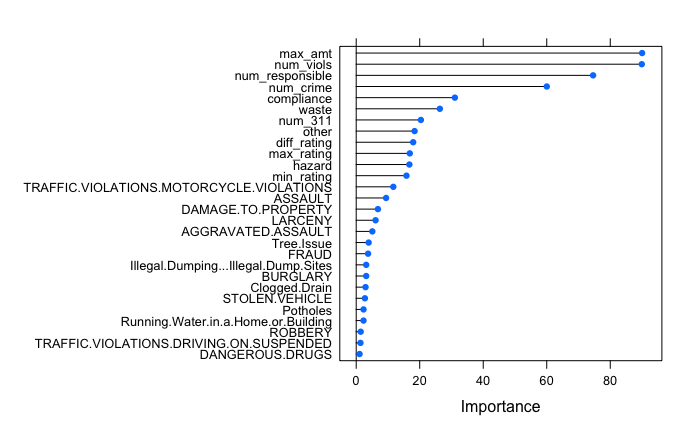

```r
rf2varImp <- varImp(rfModel2, scale = FALSE)
plot(rf2varImp, top=28)
```

```r
trainSet2 <- trainSet %>% select(max_amt, num_viols, num_responsible, num_crime, X9.1.36.a., X22.2.88, min_rating, X9.1.81.a., diff_rating, num_311, max_rating, X22.2.88.b., X9.1.43.a.....Dwelling., condition)
# random forest model
rfModel3 <- train(condition ~ .,
                  data = trainSet2,
                  method = "rf",
                  trControl = ctrl,
                  metric = "ROC"
                  )
rfModel3
```

```
Random Forest

15157 samples
   13 predictor
    2 classes: 'NOT_BLIGHTED', 'BLIGHTED'

No pre-processing
Resampling: Cross-Validated (5 fold, repeated 1 times)
Summary of sample sizes: 12125, 12126, 12126, 12125, 12126
Resampling results across tuning parameters:

  mtry  ROC        Sens       Spec
   2    0.6760596  0.5180691  0.8138017
   7    0.6608206  0.5609915  0.7487991
  13    0.6596571  0.5689498  0.7298455

ROC was used to select the optimal model using  the largest value.
The final value used for the model was mtry = 2.
```

[output not shown]

[output cut: 990 more lines]

Looking at the rate of blight by violation code, “X9.1.45” and “X9.1.43.a…..Dwelling.” (over 75%). The former being “Failure of owner to comply with an emergency or imminent danger order of one- or two-family dwelling or building” and “Failure of owner of one- or two-family dwelling to comply with an emergency or imminent danger order concerining an unsafe or unsanitary structure or unlawful occupancy”

```r
count_violtype_blighted <- trainSet %>%
  filter(condition == "BLIGHTED") %>%
  select(starts_with("X")) %>%
  colSums()
count_violtype_all <- trainSet %>%
  select(starts_with("X")) %>%
  colSums()
blightrate_by_violtype <- count_violtype_blighted / count_violtype_all
blightrate_by_violtype
```

```
             X9.1.36.a.              X9.1.81.a.                X9.1.104
              0.6228058               0.6465832               0.6317310
               X22.2.88             X22.2.88.b.                X22.2.45
              0.6719949               0.6603424               0.5709924
            X9.1.110.a.                X9.1.105 X9.1.43.a.....Dwelling.
              0.5340050               0.6105477               0.7503852
               X22.2.22                X22.2.43             X9.1.103.C.
              0.5721785               0.5966851               0.4686347
               X22.2.61                 X9.1.45                X22.2.17
              0.4122807               0.7533040               0.6712329
X9.1.82.d.....Dwelling.                X9.1.113             X22.2.88.a.
              0.5862069               0.6134969               0.5534591
               X9.1.111       X22.2.83.a..b..c.
              0.4556962               0.5272727
```

Next steps: - why 311 doesn’t have much effect? Maybe not enough representation? - How many 311 records are in modeling data? It’s the smallest set (13k records) - And how about violations & crime? Violations had the most records, 73k, crime 56k - Train ensuring the overlap data (inner join), is in the model set - investigate crime/311/viol type counts as features (like bag of words) - 311: investigate effect of time (e.g., between created and closed, or # tx / unit of time)

Other data: - MLS / Zillow (last time sold, price, # sold houses around) - Detroit Parcel data